# hwk_6

likelihood ratio tests - each of these predictors has a significant effect on pox prevalence

```r
Anova(glm_pox_bin)
```

```
## Analysis of Deviance Table (Type II tests)
##
## Response: Activepox
##              LR Chisq Df Pr(>Chisq)
## Species        645.45  3  < 2.2e-16 ***
## Elev           235.43  2  < 2.2e-16 ***
## Species:Elev    47.32  5  4.884e-09 ***
## ---
## Signif. codes:  0 '***' 0.001 '**' 0.01 '*' 0.05 '.' 0.1 ' ' 1
```

look at residual, effects plots

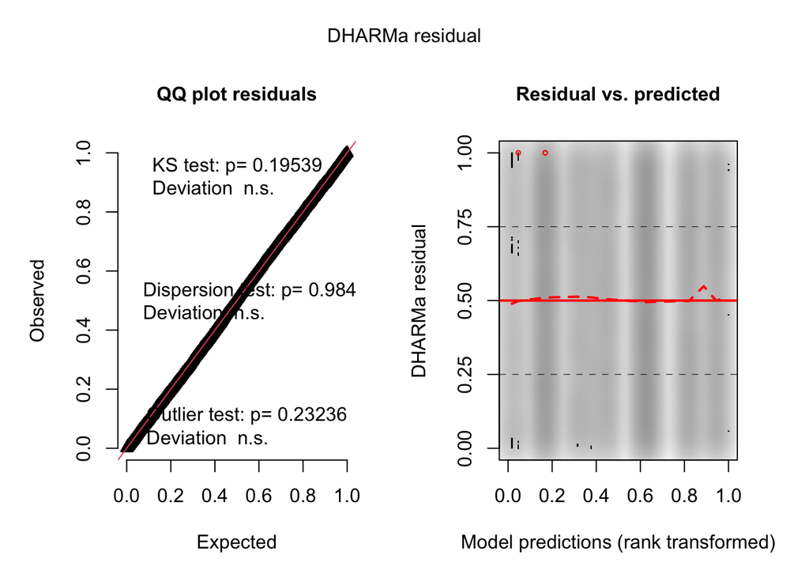

```r
sim_res_model <- simulateResiduals(fittedModel = glm_pox_bin)
plot(sim_res_model)
```

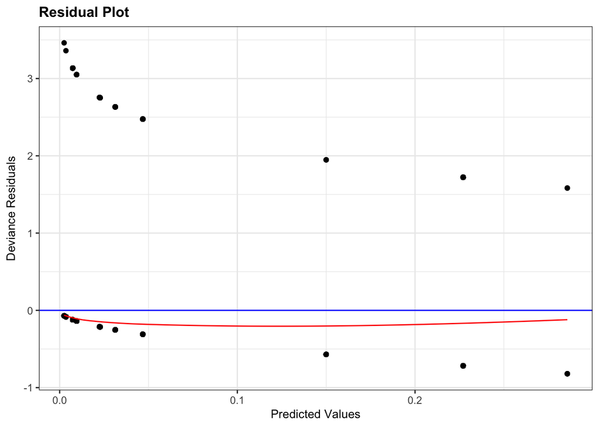

```r
resid_panel(glm_pox_bin, plots = 'resid', smoother = TRUE)
```

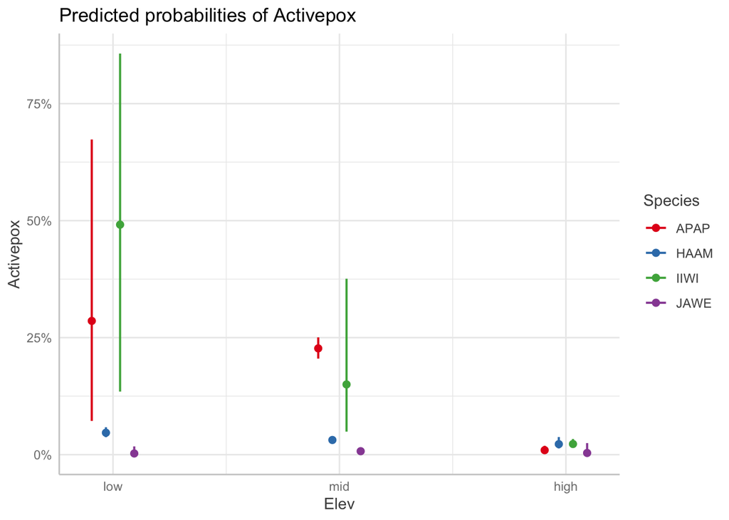

```r
plot(ggpredict(glm_pox_bin, terms = c("Elev", "Species")))
```

All residuals look great, I don’t see any issues with overdispersion - binomial distribution appears to be an appropriate choice here.

The effects plot is especially helpful - Amakihi and white eye appear resilient to pox across elevations - almost no pox at high elevations - Apapane and Iiwi highly susceptible at low and mid elevations - notice that error bars are super high at low elevations, b/c not many of these native species

#3.

filter dataset for only birds with malaria status, no Iiwi

```r
# use birds_mal from above, filter out Iiwi
birds_mal <- birds_mal %>%
  filter(Species != 'IIWI')
```

create model testing if malaria status and elevation affect pox prevalence - include species interactions for each predictor

```r
glm_pox_mal <- glm(Activepox ~ Malaria + Elev + Species*Elev + Species*Malaria,
                   data = birds_mal,
                   family = binomial)

summary(glm_pox_mal)
```

```
##
## Call:
## glm(formula = Activepox ~ Malaria + Elev + Species * Elev + Species *
##     Malaria, family = binomial, data = birds_mal)
##
## Coefficients:
##                      Estimate Std. Error z value Pr(>|z|)
## (Intercept)           -2.5745     0.8701  -2.959  0.00309 **
## Malaria                1.8277     0.1809  10.106  < 2e-16 ***
## Elevmid                0.0809     0.8562   0.094  0.92473
## Elevhigh              -2.4055     0.9410  -2.556  0.01058 *
## SpeciesHAAM           -1.2642     0.9019  -1.402  0.16097
## Elevmid:SpeciesHAAM    0.0301     0.8823   0.034  0.97278
## Elevhigh:SpeciesHAAM   2.5614     1.0085   2.540  0.01109 *
## Malaria:SpeciesHAAM   -0.8783     0.2797  -3.140  0.00169 **
## ---
## Signif. codes:  0 '***' 0.001 '**' 0.01 '*' 0.05 '.' 0.1 ' ' 1
##
## (Dispersion parameter for binomial family taken to be 1)
##
##     Null deviance: 3276.3  on 6570  degrees of freedom
## Residual deviance: 2624.3  on 6563  degrees of freedom
## AIC: 2640.3
##
## Number of Fisher Scoring iterations: 7
```

interpreting model summary - malaria has a significant positive effect on pox prevalence - high elevations have a significantly lower pox prevalence than low and mid - interactions show species dependent effects - Amakihi are sig less likely to have pox if they have malaria than other species(?) - Amakihi are sig more likely to have pox at high elevations compared to other species(?)

evaluate model - each of these predictors and the interactions have significant effects

```r
Anova(glm_pox_mal)
```

```
## Analysis of Deviance Table (Type II tests)
##
## Response: Activepox
##                 LR Chisq Df Pr(>Chisq)
## Malaria          141.429  1  < 2.2e-16 ***
## Elev              46.717  2  7.169e-11 ***
## Species          151.175  1  < 2.2e-16 ***
## Elev:Species      25.947  2  2.322e-06 ***
## Malaria:Species   10.184  1   0.001416 **
## ---
## Signif. codes:  0 '***' 0.001 '**' 0.01 '*' 0.05 '.' 0.1 ' ' 1
```

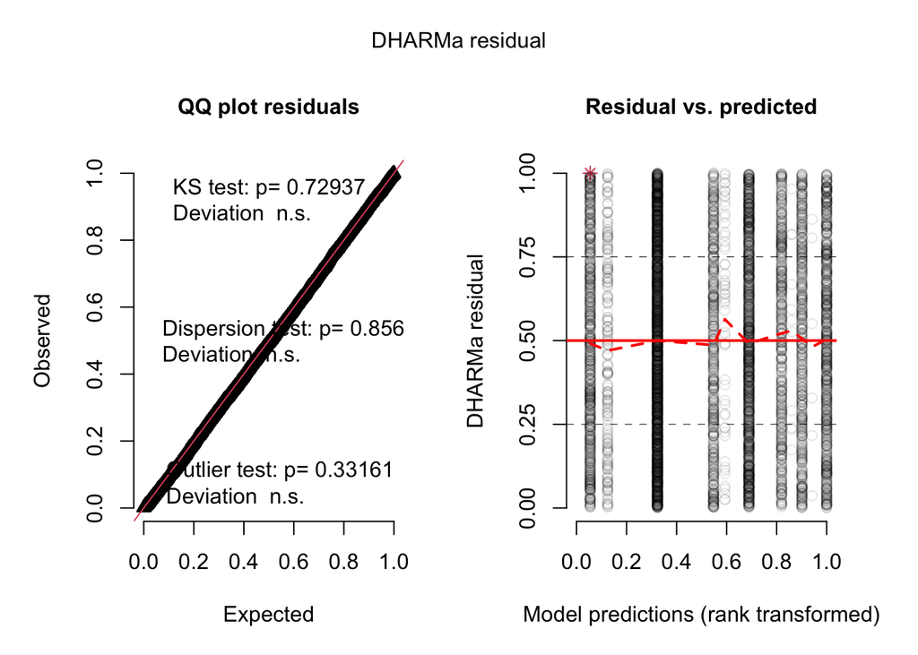

```r
sim_res_model <- simulateResiduals(fittedModel = glm_pox_mal)
plot(sim_res_model)
```

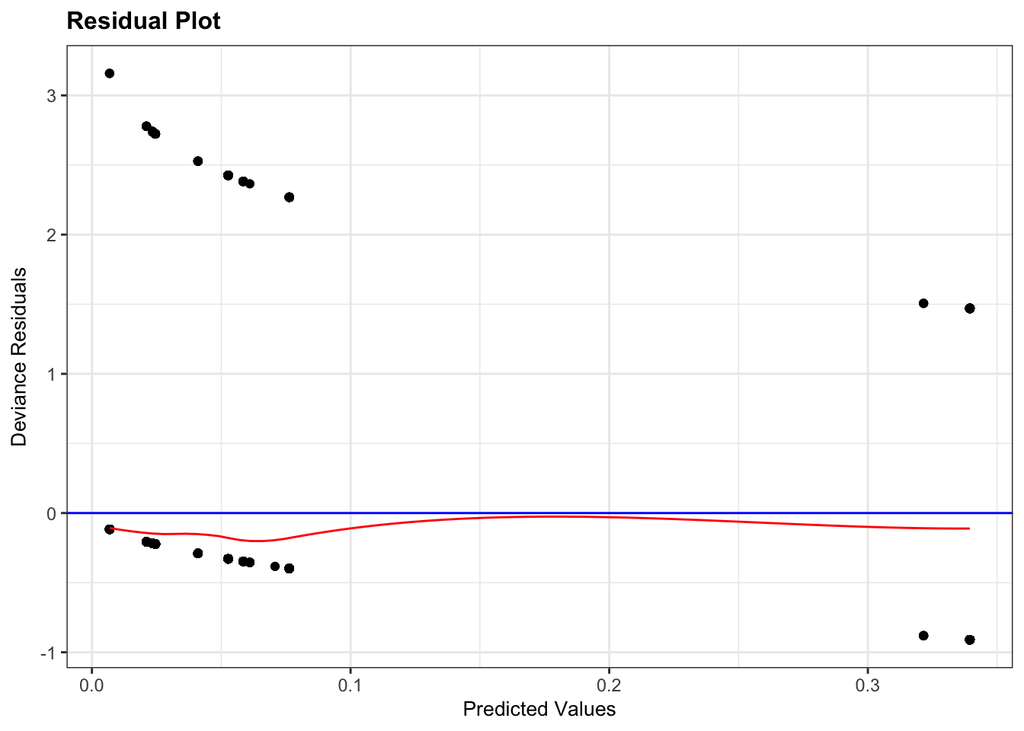

```r
resid_panel(glm_pox_mal, plots = 'resid', smoother = TRUE)
```

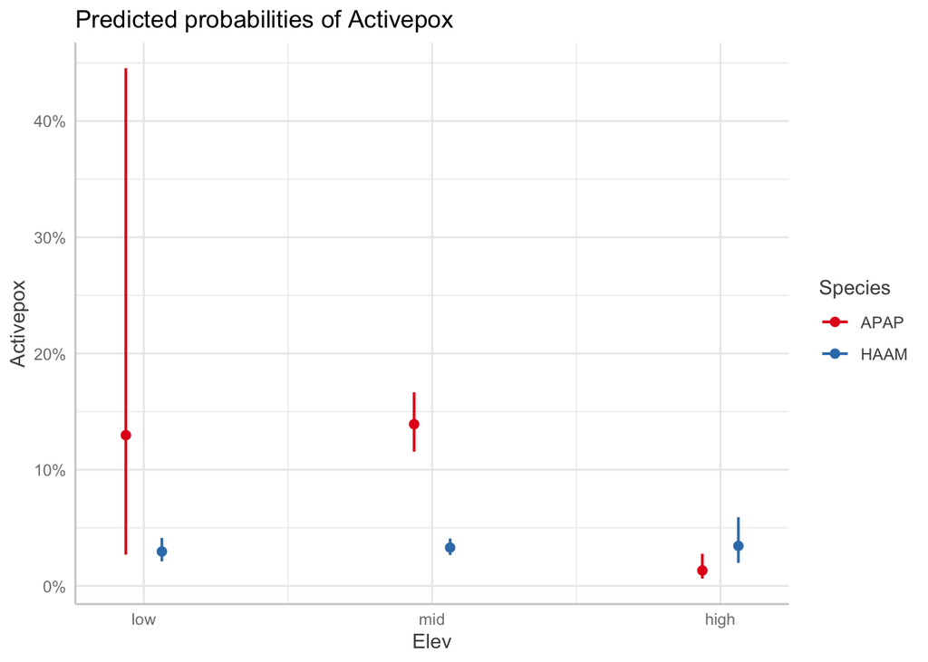

```r
plot(ggpredict(glm_pox_mal, terms = c("Elev", "Species")))
```

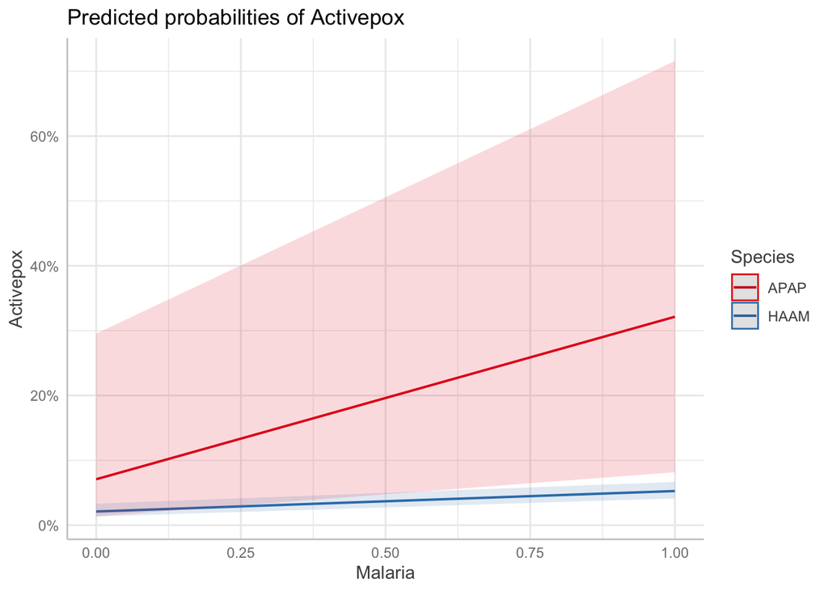

```r
plot(ggpredict(glm_pox_mal, terms = c("Malaria", "Species")))
```

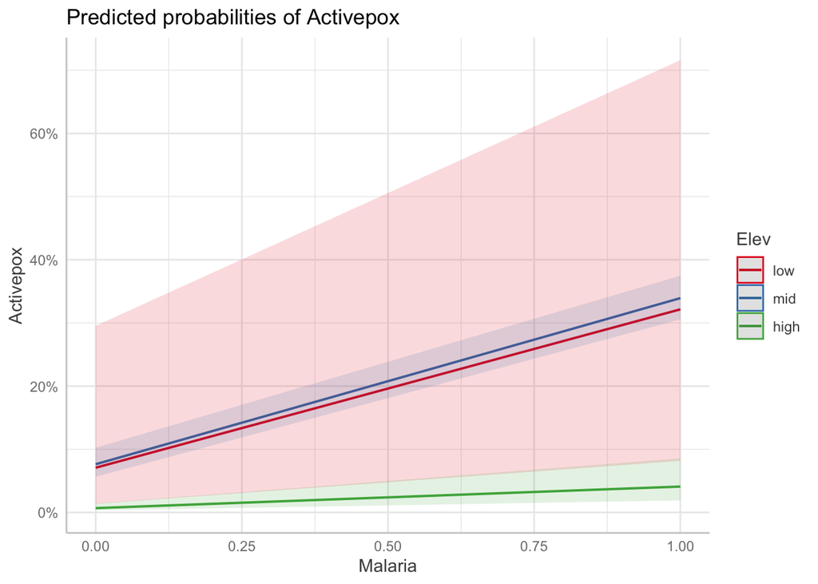

```r
plot(ggpredict(glm_pox_mal, terms = c("Malaria", "Elev")))
```